# Efficiency by origin of fish released

This document compares RST efficiency trial values by origin of fish released (`origin_released` in `SRJPEdata::weekly_efficiency`). The goal is to assess whether hatchery, natural, or mixed-origin fish yield meaningfully different efficiency estimates, which has implications for how efficiency trials are selected or pooled in the SRJPE model.

Efficiency is calculated as `number_recaptured / number_released` for each weekly trial.

# Overview of origin coverage

Number of weekly trials by year, stream, site, and origin

| Stream | Site | site_group | week_released | Year | Origin | N trials |
| --- | --- | --- | --- | --- | --- | --- |
| battle creek | ubc | battle creek | 2 | 2004 | natural | 1 |
| battle creek | ubc | battle creek | 4 | 2004 | natural | 1 |
| battle creek | ubc | battle creek | 5 | 2004 | natural | 1 |
| battle creek | ubc | battle creek | 6 | 2004 | natural | 1 |
| battle creek | ubc | battle creek | 7 | 2004 | natural | 1 |
| battle creek | ubc | battle creek | 8 | 2004 | natural | 1 |
| battle creek | ubc | battle creek | 10 | 2004 | natural | 1 |
| battle creek | ubc | battle creek | 11 | 2004 | natural | 1 |
| battle creek | ubc | battle creek | 13 | 2004 | natural | 1 |
| battle creek | ubc | battle creek | 14 | 2004 | natural | 1 |
| battle creek | ubc | battle creek | 15 | 2004 | natural | 1 |
| battle creek | ubc | battle creek | 16 | 2004 | natural | 1 |
| battle creek | ubc | battle creek | 1 | 2005 | natural | 1 |
| battle creek | ubc | battle creek | 2 | 2005 | natural | 1 |
| battle creek | ubc | battle creek | 3 | 2005 | natural | 1 |
| battle creek | ubc | battle creek | 4 | 2005 | natural | 1 |
| battle creek | ubc | battle creek | 5 | 2005 | natural | 1 |
| battle creek | ubc | battle creek | 6 | 2005 | natural | 1 |
| battle creek | ubc | battle creek | 7 | 2005 | natural | 1 |
| battle creek | ubc | battle creek | 8 | 2005 | natural | 1 |
| battle creek | ubc | battle creek | 9 | 2005 | natural | 1 |
| battle creek | ubc | battle creek | 10 | 2005 | natural | 1 |
| battle creek | ubc | battle creek | 11 | 2005 | natural | 1 |
| battle creek | ubc | battle creek | 12 | 2005 | natural | 1 |
| battle creek | ubc | battle creek | 13 | 2005 | natural | 1 |
| battle creek | ubc | battle creek | 14 | 2005 | natural | 1 |
| battle creek | ubc | battle creek | 15 | 2005 | natural | 1 |
| battle creek | ubc | battle creek | 16 | 2005 | natural | 1 |
| battle creek | ubc | battle creek | 17 | 2005 | natural | 1 |
| battle creek | ubc | battle creek | 18 | 2005 | natural | 1 |

[output cut: 1394 more lines]

**670 of 1424 trials (47%) have `NA` for `origin_released`**, including all Clear Creek trials and older records at Battle Creek, Sacramento River (pre-2015), and several Feather River sites. These are excluded from origin comparisons below.

# Overall efficiency distribution by origin

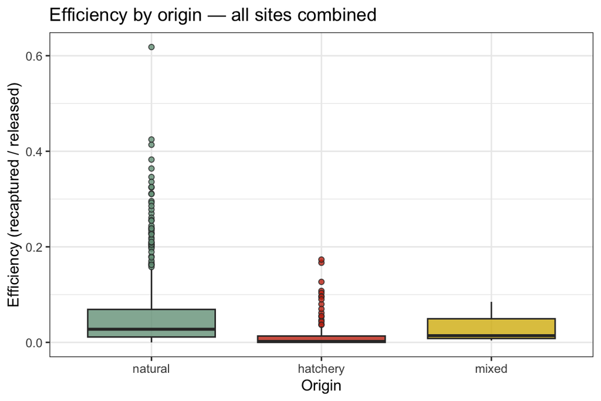

Summary statistics by origin (efficiency > 1 excluded)

| Origin | N trials | Median eff. | Mean eff. | SD | % zero recapture |
| --- | --- | --- | --- | --- | --- |
| natural | 582 | 0.0276 | 0.0542 | 0.0729 | 5.2 |
| hatchery | 149 | 0.0020 | 0.0143 | 0.0300 | 39.6 |
| mixed | 23 | 0.0141 | 0.0278 | 0.0259 | 0.0 |

# Efficiency by origin within each stream

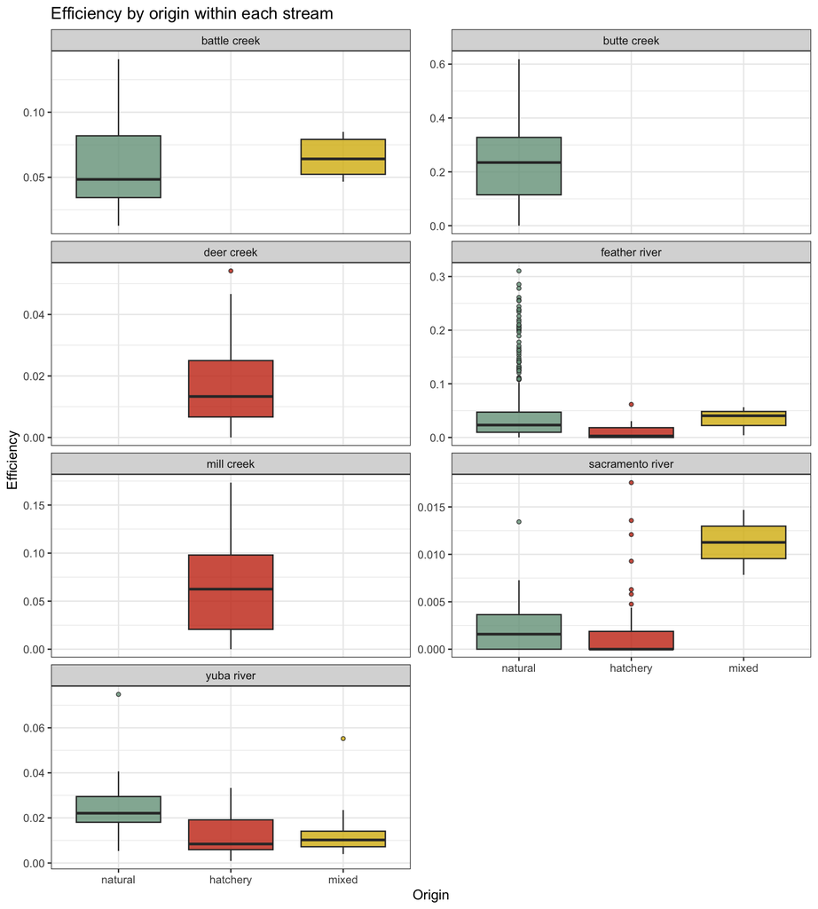

# Efficiency by origin within each site

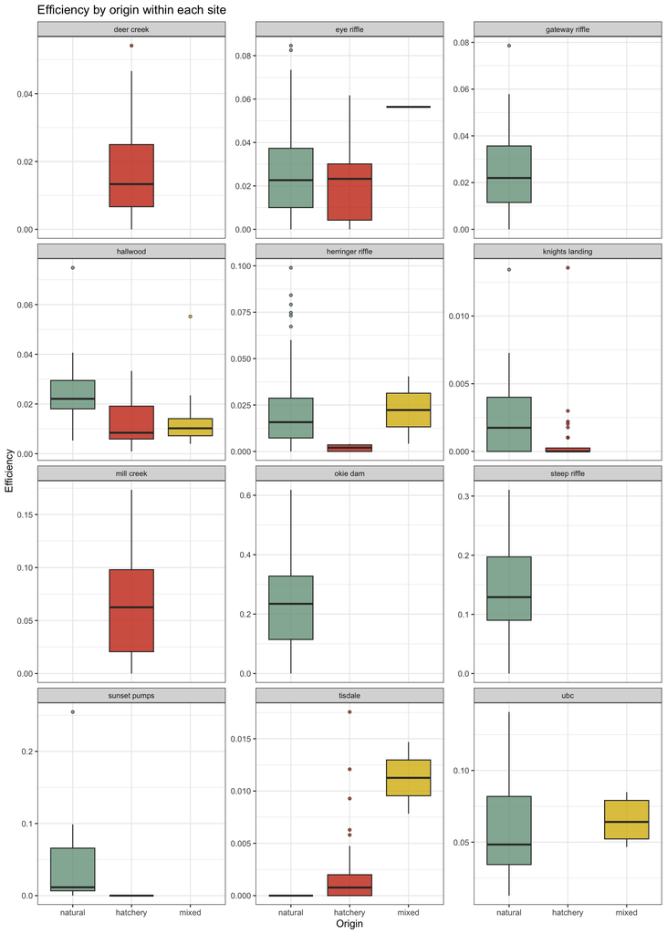